# Carregando dados, Manipulando e Visualizando

Ricardo Accioly

2022-06-24

## Lendo dados de arquivos csv

```r
library(readr)
url <- "https://www.gov.br/anp/pt-br/centrais-de-conteudo/dados-abertos/arquivos-acervo-de-dados-tecnicos/tabela-pocos.csv"
## O read_delim permite que seja definido o tipo de delimitador dos dados
pocos <- read_delim(url, delim = ";", locale= locale(decimal_mark = ","), col_names = TRUE)
head(pocos)
```

```
## # A tibble: 6 × 60
##   POCO        CADASTRO OPERADOR POCO_OPERADOR ESTADO BACIA BLOCO SIG_CAMPO CAMPO
##   <chr>       <chr>    <chr>    <chr>         <chr>  <chr> <chr> <chr>     <chr>
## 1 7-ET-1690D… 7210002… Petrobr… 7ET1690DRN    RN     Poti… ET    "ET   "   ESTR…
## 2 7-ET-1686D… 7210002… Petrobr… 7ET1686DRN    RN     Poti… ET    "ET   "   ESTR…
## 3 7-ET-1684-… 7210002… Petrobr… 7ET1684RN     RN     Poti… ET    "ET   "   ESTR…
## 4 7-ET-1681D… 7210002… Petrobr… 7ET1681DRN    RN     Poti… ET    "ET   "   ESTR…
## 5 7-ET-1679D… 7210002… Petrobr… 7ET1679DRN    RN     Poti… ET    "ET   "   ESTR…
## 6 7-ET-1677-… 7210002… Petrobr… 7ET1677RN     RN     Poti… ET    "ET   "   ESTR…
## # … with 51 more variables: TERRA_MAR <chr>, POCO_POS_ANP <chr>, TIPO <chr>,
## #   CATEGORIA <chr>, RECLASSIFICACAO <chr>, SITUACAO <chr>, INICIO <chr>,
## #   TERMINO <chr>, CONCLUSAO <chr>, TITULARIDADE <chr>, LATITUDE_BASE_4C <chr>,
## #   LONGITUDE_BASE_4C <chr>, LATITUDE_BASE_DD <dbl>, LONGITUDE_BASE_DD <dbl>,
## #   DATUM_HORIZONTAL <chr>, TIPO_DE_COORDENADA_DE_BASE <chr>, DIRECAO <chr>,
## #   PROFUNDIDADE_VERTICAL_M <dbl>, PROFUNDIDADE_SONDADOR_M <dbl>,
## #   PROFUNDIDADE_MEDIDA_M <dbl>, REFERENCIA_DE_PROFUNDIDADE <chr>, …
```

## Bibliotecas

Vamos carregar as bibliotecas que serão usadas na manipulação e visualização de dados.

O pacote tidyverse carrega diversos pacotes muito uteis na manipulação e visualização de dados

```r
library("tidyverse")
```

Vamos primeiro conhecer o que tem na base de dados pocos. A base de dados possui 30241 linhas

```r
class(pocos)  # Tipo de base de dados
```

```
## [1] "spec_tbl_df" "tbl_df"      "tbl"         "data.frame"
```

```r
summary(pocos) # Sumario da base de dados
```

```
##      POCO             CADASTRO           OPERADOR         POCO_OPERADOR
##  Length:30241       Length:30241       Length:30241       Length:30241
##  Class :character   Class :character   Class :character   Class :character
##  Mode  :character   Mode  :character   Mode  :character   Mode  :character
##
##
##
##
##     ESTADO             BACIA              BLOCO            SIG_CAMPO
##  Length:30241       Length:30241       Length:30241       Length:30241
##  Class :character   Class :character   Class :character   Class :character
##  Mode  :character   Mode  :character   Mode  :character   Mode  :character
##
##
##
##
##     CAMPO            TERRA_MAR         POCO_POS_ANP           TIPO
##  Length:30241       Length:30241       Length:30241       Length:30241
##  Class :character   Class :character   Class :character   Class :character
##  Mode  :character   Mode  :character   Mode  :character   Mode  :character
##
##
##
##
##   CATEGORIA         RECLASSIFICACAO      SITUACAO            INICIO
##  Length:30241       Length:30241       Length:30241       Length:30241
##  Class :character   Class :character   Class :character   Class :character
##  Mode  :character   Mode  :character   Mode  :character   Mode  :character
##
##
##
##
##    TERMINO           CONCLUSAO         TITULARIDADE       LATITUDE_BASE_4C
##  Length:30241       Length:30241       Length:30241       Length:30241
##  Class :character   Class :character   Class :character   Class :character
##  Mode  :character   Mode  :character   Mode  :character   Mode  :character
##
##
##
##
```

[output cut: 73 more lines]

```
##  Length:30241       Length:30241       Length:30241       Length:30241
##  Class :character   Class :character   Class :character   Class :character
##  Mode  :character   Mode  :character   Mode  :character   Mode  :character
##
##
##
##
##   SIG_SONDA          NOM_SONDA         DHA_ATUALIZACAO    ATINGIU_PRESAL
##  Length:30241       Length:30241       Length:30241       Length:30241
##  Class :character   Class :character   Class :character   Class :character
##  Mode  :character   Mode  :character   Mode  :character   Mode  :character
##
##
##
##
```

## Dados de poços

Os dados da tabela poços tem 60 colunas.

Vamos inicialmente selecionar algumas colunas para podermos trabalhar com os dados.

**As colunas que vamos trabalhar são:**

1. POCO
2. OPERADOR
3. ESTADO
4. BACIA
5. BLOCO
6. CAMPO
7. TERRA_MAR
8. CATEGORIA
9. SITUACAO
10. INICIO
11. TERMINO
12. PROFUNDIDADE_MEDIDA_M

Para selecionar colunas usamos a função `select`

```r
## Vamos selecionar as colunas listadas acima
pocos_01 <- pocos %>% select(POCO,OPERADOR,ESTADO,BACIA,BLOCO, CAMPO,TERRA_MAR,CATEGORIA,SITUACAO, INICIO, TERMINO, PROFUNDIDADE_MEDIDA_M)
head(pocos_01)
```

```
## # A tibble: 6 × 12
##   POCO     OPERADOR ESTADO BACIA BLOCO CAMPO TERRA_MAR CATEGORIA SITUACAO INICIO
##   <chr>    <chr>    <chr>  <chr> <chr> <chr> <chr>     <chr>     <chr>    <chr>
## 1 7-ET-16… Petrobr… RN     Poti… ET    ESTR… T         Desenvol… FECHADO  01/07…
## 2 7-ET-16… Petrobr… RN     Poti… ET    ESTR… T         Desenvol… FECHADO  26/11…
## 3 7-ET-16… Petrobr… RN     Poti… ET    ESTR… T         Desenvol… FECHADO  10/06…
## 4 7-ET-16… Petrobr… RN     Poti… ET    ESTR… T         Desenvol… FECHADO  12/04…
## 5 7-ET-16… Petrobr… RN     Poti… ET    ESTR… T         Desenvol… FECHADO  14/07…
## 6 7-ET-16… Petrobr… RN     Poti… ET    ESTR… T         Desenvol… FECHADO  09/04…
## # … with 2 more variables: TERMINO <chr>, PROFUNDIDADE_MEDIDA_M <dbl>
```

## Manipulação de dados

Vamos eliminar as linhas de dados que apresenta dados ausentes “NA” nas colunas TERMINO e PROFUNDIDADE_MEDIDA_M.

```r
sum(is.na(pocos_01))
```

```
## [1] 30217
```

```r
sum(is.na(pocos_01$INICIO))
```

```
## [1] 0
```

```r
sum(is.na(pocos_01$TERMINO))
```

```
## [1] 1853
```

```r
sum(is.na(pocos_01$PROFUNDIDADE_MEDIDA_M))
```

```
## [1] 17794
```

```r
pocos_01 <- pocos_01 %>% drop_na(any_of(c("TERMINO",
                                          "PROFUNDIDADE_MEDIDA_M")))
# melhorando a visualização dos dados
knitr::kable(
  head(pocos_01, 10), booktabs = TRUE,
  caption = 'Uma tabela mais elegante com as 10 primeras linhas de pocos_01.')
```

Uma tabela mais elegante com as 10 primeras linhas de pocos_01.

| POCO | OPERADOR | ESTADO | BACIA | BLOCO | CAMPO | TERRA_MAR | CATEGORIA | SITUACAO | INICIO | TERMINO | PROFUNDIDADE_MEDIDA_M |
| --- | --- | --- | --- | --- | --- | --- | --- | --- | --- | --- | --- |
| 7-ET-1690D-RN | Petrobras | RN | Potiguar | ET | ESTREITO | T | Desenvolvimento | FECHADO | 01/07/2017 00:00 | 02/07/2017 00:00 | 292.8 |
| 7-ET-1684-RN | Petrobras | RN | Potiguar | ET | ESTREITO | T | Desenvolvimento | FECHADO | 10/06/2017 00:00 | 12/06/2017 00:00 | 276.0 |
| 7-ET-1681D-RN | Petrobras | RN | Potiguar | ET | ESTREITO | T | Desenvolvimento | FECHADO | 12/04/2017 00:00 | 14/04/2017 00:00 | 295.6 |
| 7-ET-1679D-RN | Petrobras | RN | Potiguar | ET | ESTREITO | T | Desenvolvimento | FECHADO | 14/07/2017 00:00 | 15/07/2017 00:00 | 306.5 |
| 7-ET-1677-RN | Petrobras | RN | Potiguar | ET | ESTREITO | T | Desenvolvimento | FECHADO | 09/04/2017 00:00 | 09/04/2017 00:00 | 277.0 |
| 7-ET-1674-RN | Petrobras | RN | Potiguar | ET | ESTREITO | T | Desenvolvimento | FECHADO | 12/05/2017 00:00 | 14/05/2017 00:00 | 284.4 |
| 7-ET-1673-RN | Petrobras | RN | Potiguar | NA | ESTREITO | T | Desenvolvimento | FECHADO | 20/10/2017 00:00 | 21/10/2017 00:00 | 273.6 |
| 7-ET-1714D-RN | Petrobras | RN | Potiguar | ET | ESTREITO | T | Desenvolvimento | FECHADO | 20/07/2017 00:00 | 21/07/2017 00:00 | 295.0 |
| 7-ET-1713-RN | Petrobras | RN | Potiguar | ET | ESTREITO | T | Desenvolvimento | FECHADO | 25/06/2017 00:00 | 26/06/2017 00:00 | 283.3 |
| 7-ET-1710-RN | Petrobras | RN | Potiguar | ET | ESTREITO | T | Desenvolvimento | FECHADO | 28/06/2017 00:00 | 28/06/2017 00:00 | 281.0 |

```r
sum(is.na(pocos_01))
```

```
## [1] 4324
```

**Veja que existia um grande número de dados ausentes**

Antes: 30241 linhas Depois: 10702 linhas

## Corrigindo tipo de dados

As colunas INICIO e TERMINO são datas, mas foram lidas como caracter, vamos corrigir isto!

Para trabalhar com datas vamos usar o pacote `lubridate`

```r
library(lubridate)
pocos_01$INICIO <- as_date(pocos_01$INICIO, format="%d/%m/%Y")
pocos_01$TERMINO <- as_date(pocos_01$TERMINO, format="%d/%m/%Y")
```

## Filtrando dados

Vamos analisar os poços de uma detreminada região, para isto podemos fltrar os poços de um bloco. Vamos filtrar somente os poços do CAMPO PEREGRINO usando a função `filter`.

```r
pocos_02 <- pocos_01 %>% filter(CAMPO=="PEREGRINO") ##
summary(pocos_02)
```

```
##      POCO             OPERADOR            ESTADO             BACIA
##  Length:94          Length:94          Length:94          Length:94
##  Class :character   Class :character   Class :character   Class :character
##  Mode  :character   Mode  :character   Mode  :character   Mode  :character
##
##
##
##     BLOCO              CAMPO            TERRA_MAR          CATEGORIA
##  Length:94          Length:94          Length:94          Length:94
##  Class :character   Class :character   Class :character   Class :character
##  Mode  :character   Mode  :character   Mode  :character   Mode  :character
##
##
##
##    SITUACAO             INICIO              TERMINO
##  Length:94          Min.   :1994-07-07   Min.   :1994-08-17
##  Class :character   1st Qu.:2011-12-16   1st Qu.:2012-01-27
##  Mode  :character   Median :2013-07-02   Median :2013-08-31
##                     Mean   :2013-11-27   Mean   :2013-12-27
##                     3rd Qu.:2015-10-06   3rd Qu.:2015-10-29
##                     Max.   :2022-02-25   Max.   :2022-03-09
##  PROFUNDIDADE_MEDIDA_M
##  Min.   :   0
##  1st Qu.:4457
##  Median :4925
##  Mean   :5136
##  3rd Qu.:6213
##  Max.   :8613
```

```r
knitr::kable(
  head(pocos_02, 10), booktabs = TRUE,
  caption = 'Uma tabela mais elegante com as 10 primeras linhas de pocos_02.')
```

Uma tabela mais elegante com as 10 primeras linhas de pocos_02.

| POCO | OPERADOR | ESTADO | BACIA | BLOCO | CAMPO | TERRA_MAR | CATEGORIA | SITUACAO | INICIO | TERMINO | PROFUNDIDADE_MEDIDA_M |
| --- | --- | --- | --- | --- | --- | --- | --- | --- | --- | --- | --- |
| 7-PRG-41HA-RJS | Equinor Brasil | RJ | Campos | NA | PEREGRINO | M | Desenvolvimento | FECHADO | 2014-11-07 | 2014-11-11 | 4543.00 |
| 7-PRG-43H-RJS | Equinor Brasil | RJ | Campos | NA | PEREGRINO | M | Desenvolvimento | FECHADO | 2014-12-21 | 2015-01-18 | 6382.80 |
| 7-PRG-58H-RJS | Equinor Brasil | RJ | Campos | BM-C-7 | PEREGRINO | M | Desenvolvimento | ABANDONADO PERMANENTEMENTE | 2017-02-25 | 2017-04-09 | 6762.00 |
| 7-PRG-57HA-RJS | Equinor Brasil | RJ | Campos | NA | PEREGRINO | M | Desenvolvimento | FECHADO | 2017-01-15 | 2017-01-20 | 8613.00 |
| 7-PRG-48H-RJS | Equinor Brasil | RJ | Campos | NA | PEREGRINO | M | Desenvolvimento | ABANDONADO PERMANENTEMENTE | 2015-06-16 | 2015-07-06 | 5765.50 |
| 7-PRG-53H-RJS | Equinor Brasil | RJ | Campos | NA | PEREGRINO | M | Desenvolvimento | FECHADO | 2015-11-12 | 2015-12-09 | 5495.70 |
| 7-PRG-42H-RJS | Equinor Brasil | RJ | Campos | NA | PEREGRINO | M | Desenvolvimento | FECHADO | 2014-12-03 | 2014-12-29 | 5555.00 |
| 7-PRG-57H-RJS | Equinor Brasil | RJ | Campos | NA | PEREGRINO | M | Desenvolvimento | ABANDONADO PERMANENTEMENTE | 2016-11-26 | 2016-12-18 | 6532.72 |
| 7-PRG-47H-RJS | Equinor Brasil | RJ | Campos | NA | PEREGRINO | M | Desenvolvimento | FECHADO | 2015-05-12 | 2015-05-29 | 4661.00 |
| 7-PRG-49H-RJS | Equinor Brasil | RJ | Campos | NA | PEREGRINO | M | Desenvolvimento | FECHADO | 2015-06-28 | 2015-08-21 | 8080.20 |

### Avaliando os dados

```r
unique(pocos_02$CATEGORIA)
```

```
## [1] "Desenvolvimento" "Extensão"        "Pioneiro"        "Injeção"
## [5] "Especial"
```

### Filtrando poços de desenvolvimento

```r
pocos_03 <- pocos_02 %>% filter(CATEGORIA=="Desenvolvimento") ##
summary(pocos_03)
```

```
##      POCO             OPERADOR            ESTADO             BACIA
##  Length:73          Length:73          Length:73          Length:73
##  Class :character   Class :character   Class :character   Class :character
##  Mode  :character   Mode  :character   Mode  :character   Mode  :character
##
##
##
##     BLOCO              CAMPO            TERRA_MAR          CATEGORIA
##  Length:73          Length:73          Length:73          Length:73
##  Class :character   Class :character   Class :character   Class :character
##  Mode  :character   Mode  :character   Mode  :character   Mode  :character
##
##
##
##    SITUACAO             INICIO              TERMINO
##  Length:73          Min.   :2010-11-10   Min.   :2010-11-11
##  Class :character   1st Qu.:2012-02-04   1st Qu.:2012-04-06
##  Mode  :character   Median :2013-10-20   Median :2013-11-15
##                     Mean   :2014-07-23   Mean   :2014-08-21
##                     3rd Qu.:2016-06-23   3rd Qu.:2016-08-27
##                     Max.   :2022-02-25   Max.   :2022-03-09
##  PROFUNDIDADE_MEDIDA_M
##  Min.   : 742
##  1st Qu.:4543
##  Median :5066
##  Mean   :5385
##  3rd Qu.:6383
##  Max.   :8613
```

```r
knitr::kable(
  head(pocos_03, 10), booktabs = TRUE,
  caption = 'Uma tabela mais elegante com as 10 primeras linhas de pocos_03.')
```

Uma tabela mais elegante com as 10 primeras linhas de pocos_03.

| POCO | OPERADOR | ESTADO | BACIA | BLOCO | CAMPO | TERRA_MAR | CATEGORIA | SITUACAO | INICIO | TERMINO | PROFUNDIDADE_MEDIDA_M |
| --- | --- | --- | --- | --- | --- | --- | --- | --- | --- | --- | --- |
| 7-PRG-41HA-RJS | Equinor Brasil | RJ | Campos | NA | PEREGRINO | M | Desenvolvimento | FECHADO | 2014-11-07 | 2014-11-11 | 4543.00 |
| 7-PRG-43H-RJS | Equinor Brasil | RJ | Campos | NA | PEREGRINO | M | Desenvolvimento | FECHADO | 2014-12-21 | 2015-01-18 | 6382.80 |
| 7-PRG-58H-RJS | Equinor Brasil | RJ | Campos | BM-C-7 | PEREGRINO | M | Desenvolvimento | ABANDONADO PERMANENTEMENTE | 2017-02-25 | 2017-04-09 | 6762.00 |
| 7-PRG-57HA-RJS | Equinor Brasil | RJ | Campos | NA | PEREGRINO | M | Desenvolvimento | FECHADO | 2017-01-15 | 2017-01-20 | 8613.00 |
| 7-PRG-48H-RJS | Equinor Brasil | RJ | Campos | NA | PEREGRINO | M | Desenvolvimento | ABANDONADO PERMANENTEMENTE | 2015-06-16 | 2015-07-06 | 5765.50 |
| 7-PRG-53H-RJS | Equinor Brasil | RJ | Campos | NA | PEREGRINO | M | Desenvolvimento | FECHADO | 2015-11-12 | 2015-12-09 | 5495.70 |
| 7-PRG-42H-RJS | Equinor Brasil | RJ | Campos | NA | PEREGRINO | M | Desenvolvimento | FECHADO | 2014-12-03 | 2014-12-29 | 5555.00 |
| 7-PRG-57H-RJS | Equinor Brasil | RJ | Campos | NA | PEREGRINO | M | Desenvolvimento | ABANDONADO PERMANENTEMENTE | 2016-11-26 | 2016-12-18 | 6532.72 |
| 7-PRG-47H-RJS | Equinor Brasil | RJ | Campos | NA | PEREGRINO | M | Desenvolvimento | FECHADO | 2015-05-12 | 2015-05-29 | 4661.00 |
| 7-PRG-49H-RJS | Equinor Brasil | RJ | Campos | NA | PEREGRINO | M | Desenvolvimento | FECHADO | 2015-06-28 | 2015-08-21 | 8080.20 |

## Criando uma coluna com mutate

Vamos criar uma coluna que nos dará a duração da perfuração dos poços.

```r
pocos_03$INICIO[1]
```

```
## [1] "2014-11-07"
```

```r
pocos_03$TERMINO[1]
```

```
## [1] "2014-11-11"
```

```r
pocos_03$TERMINO[1] - pocos_03$INICIO[1]
```

```
## Time difference of 4 days
```

```r
difftime(pocos_03$TERMINO[1], pocos_03$INICIO[1], units = "days")
```

```
## Time difference of 4 days
```

```r
tempo <- difftime(pocos_03$TERMINO[1], pocos_03$INICIO[1], units = "days")
str(tempo)
```

```
##  'difftime' num 4
##  - attr(*, "units")= chr "days"
```

```r
(pocos_03$INICIO[1] %--% pocos_03$TERMINO[1])/ddays(1)
```

```
## [1] 4
```

```r
pocos_03 <- pocos_03 %>% mutate(TPERF = (INICIO %--% TERMINO)/ddays(1))
summary(pocos_03)
```

```
##      POCO             OPERADOR            ESTADO             BACIA
##  Length:73          Length:73          Length:73          Length:73
##  Class :character   Class :character   Class :character   Class :character
##  Mode  :character   Mode  :character   Mode  :character   Mode  :character
##
##
##
##     BLOCO              CAMPO            TERRA_MAR          CATEGORIA
##  Length:73          Length:73          Length:73          Length:73
##  Class :character   Class :character   Class :character   Class :character
##  Mode  :character   Mode  :character   Mode  :character   Mode  :character
##
##
##
##    SITUACAO             INICIO              TERMINO
##  Length:73          Min.   :2010-11-10   Min.   :2010-11-11
##  Class :character   1st Qu.:2012-02-04   1st Qu.:2012-04-06
##  Mode  :character   Median :2013-10-20   Median :2013-11-15
##                     Mean   :2014-07-23   Mean   :2014-08-21
##                     3rd Qu.:2016-06-23   3rd Qu.:2016-08-27
##                     Max.   :2022-02-25   Max.   :2022-03-09
##  PROFUNDIDADE_MEDIDA_M     TPERF
##  Min.   : 742          Min.   :-347.0
##  1st Qu.:4543          1st Qu.:  16.0
##  Median :5066          Median :  24.0
##  Mean   :5385          Mean   :  28.9
##  3rd Qu.:6383          3rd Qu.:  37.0
##  Max.   :8613          Max.   : 260.0
```

### Eliminando colunas com tempos negativos

```r
pocos_03 <- pocos_03 %>% filter(TPERF > 0)
```

## Visualizando os dados de PEREGRINO

### Box-Plot

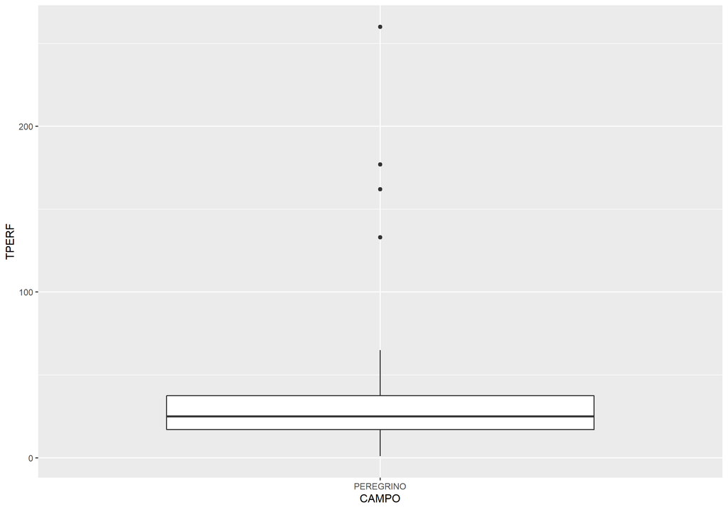

```r
ggplot(pocos_03, aes(x=CAMPO, y=TPERF)) +
  geom_boxplot()
```

Veja que existem alguns tempos bem elevados que estão representados por pontos no box-plot. Eles podem ser considerados pontos afastados (outliers), que neste caso vamos eliminar.

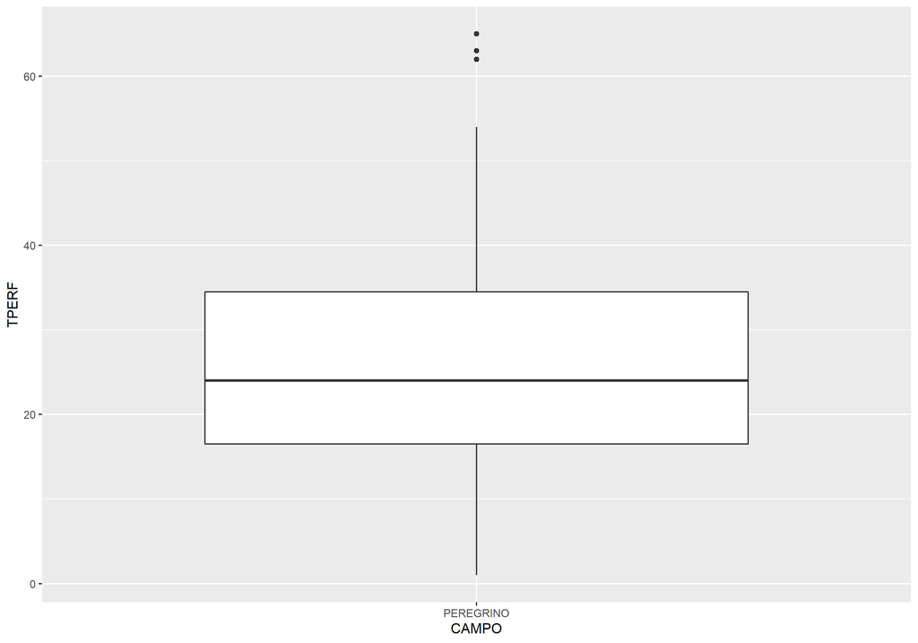

```r
pocos_04 <- pocos_03 %>% filter(TPERF < 100)
ggplot(pocos_04, aes(x=CAMPO, y=TPERF)) +
  geom_boxplot()
```

### Histograma

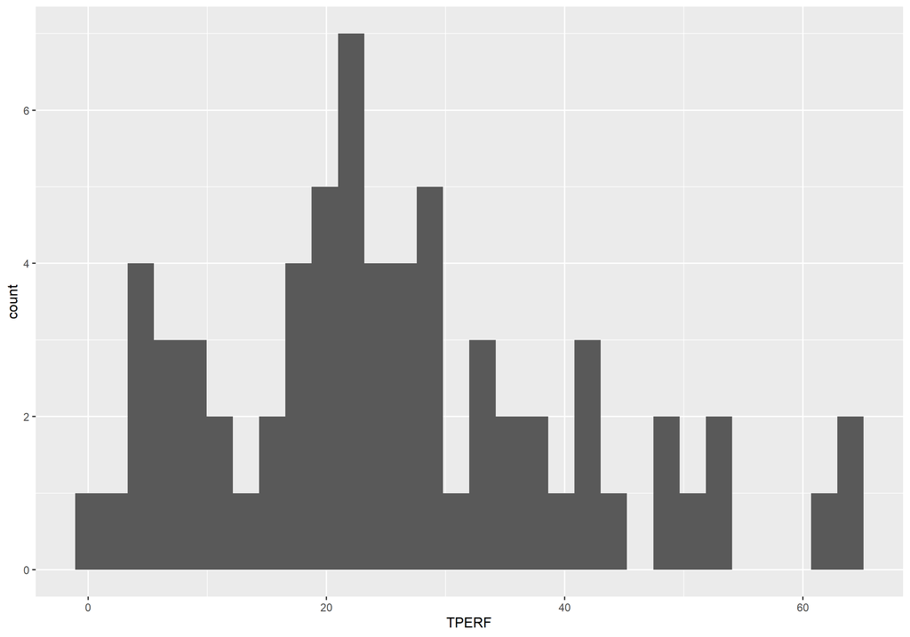

```r
ggplot(pocos_04, aes(x=TPERF)) +
  geom_histogram()
```

Veja que desta forma o ggplot usa o seu padrão de 30 faixas de dados, que geralmente não é o mais adequado.

Vamos usar uma regra adequada para definição de número de faixas.

### Criando um histograma usando a regra de Sturges

A regra de Sturges indica 7 faixas enquanto que o padrão do ggplot2 é 30.

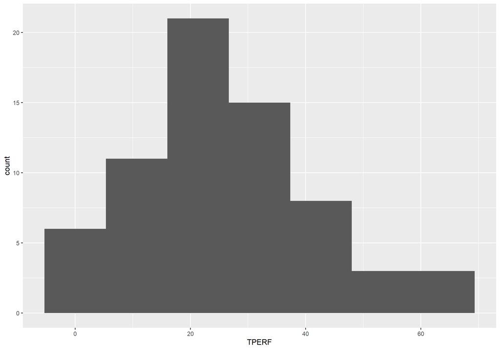

```r
ggplot(pocos_04, aes(x = TPERF)) +
  geom_histogram(bins = round(1+3.322*log10(nrow(pocos_04)),0))
```

Veja que agora temos um histograma mais suave.

### Gráfico de Dispersão

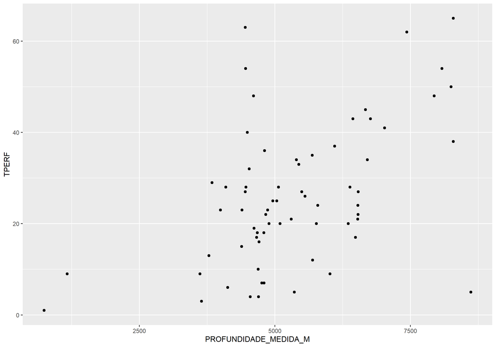

```r
ggplot(pocos_04, aes(x=PROFUNDIDADE_MEDIDA_M, y=TPERF)) +
  geom_point()
```

Podemos perceber que há uma relação entre o tempo de perfuração e a profundidade do poço.

Também é possível se perceber que ainda existem dados com comportamentos estranhos. Poços rasos com profundidade muito diferente dos demais, além disso um poço muito profundo com duração muito pequena.

Se fossemos construir um modelo certamente terímos que investigar o porque destes comportamentos.

### Alterando nome das colunas

```r
names(pocos_04)
```

```
##  [1] "POCO"                  "OPERADOR"              "ESTADO"
##  [4] "BACIA"                 "BLOCO"                 "CAMPO"
##  [7] "TERRA_MAR"             "CATEGORIA"             "SITUACAO"
## [10] "INICIO"                "TERMINO"               "PROFUNDIDADE_MEDIDA_M"
## [13] "TPERF"
```

```r
names(pocos_04) <- tolower(names(pocos_04))
names(pocos_04)
```

```
##  [1] "poco"                  "operador"              "estado"
##  [4] "bacia"                 "bloco"                 "campo"
##  [7] "terra_mar"             "categoria"             "situacao"
## [10] "inicio"                "termino"               "profundidade_medida_m"
## [13] "tperf"
```